# WPB Drought

Zjrobbin

6/12/2020

### Palmers Drought Severity Index

https://developers.google.com/earth-engine/datasets/catalog/IDAHO_EPSCOR_PDSI

This is from the same group that produced MACA they have Palmers drought severity index going back ot 1979 on a thrice monthly timestep (1,10,20th) From the description

"The Palmer Drought Severity Index dataset provides high spatial resolution (~4-km) thrice-monthly estimates of this widely used measure of integrated water supply and demand anomalies across the contiguous United States from 1979-present. The PDSI is calculated using precipitation and potential evapotranspiration derived from the gridded meteorological dataset of Abatzoglou (2013).

Potential evapotranspiration is computed using the Penman-Montieth equation for a reference grass surface. Available soil water holding capacity in the top 2.5m of the soil was derived from the STATSGO soils database and used in the computations. Whereas PDSI has typically been computed on monthly timescales, we compute these data three-times a month to provide more timely updates. Due to the spin-up of PDSI calculations, data for the first year of record should be used sparingly.

This dataset contains provisional products that are replaced with updated versions when the complete source data become available. Products can be distinguished by the value of the ‘status’ property. At first, assets are ingested with status=‘early’. After several days, they are replaced by assets with status=‘provisional’. After about 2 months, they are replaced by the final assets with status=‘permanent’."

I took the average bounded by the shape file for each of the WPB Locations

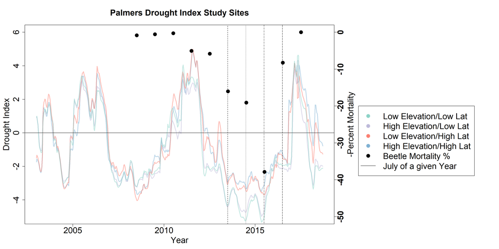

## SPI (Four Year)

Standardize precipitation index is $\frac{Precip-Mean Hist Precip}{(SD of Hist Precip)}$

From Gavin D. Madakumbura and Michael L. Goulden’s manuscript. They tested several drought indices for the area and settled on a 4 year lg SPI. This only takes precip as an input.

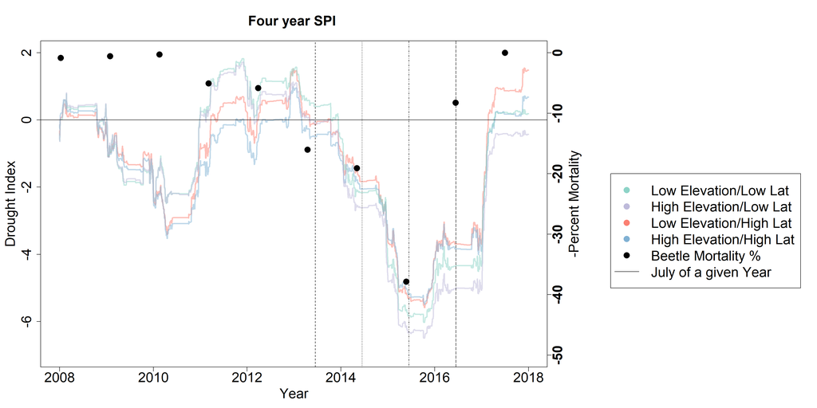

### Current Drought Index

Normalize P-ET to th emean for the period between 2001-2010 Rollling Cumulative Drought

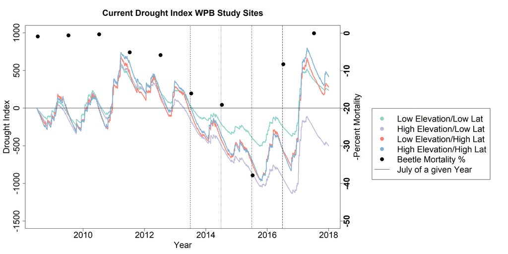

#### Five Year Lag

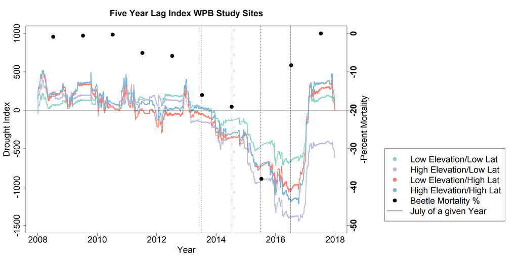

### Four Year Lag

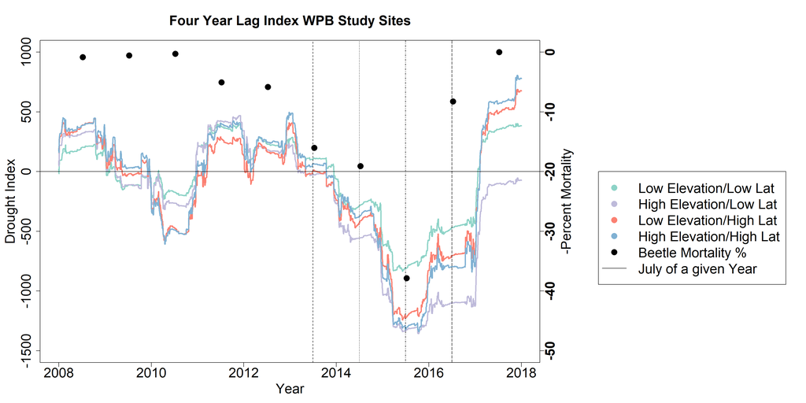

### Three Year Lag

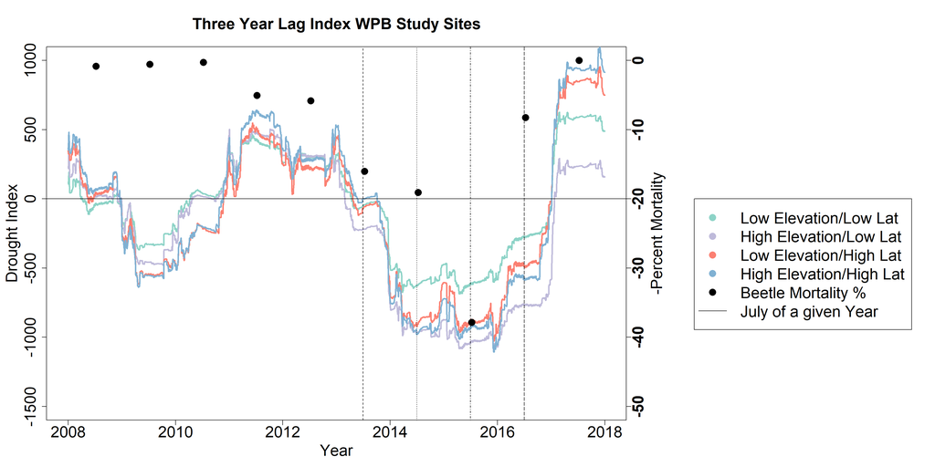

### Two Year Lag

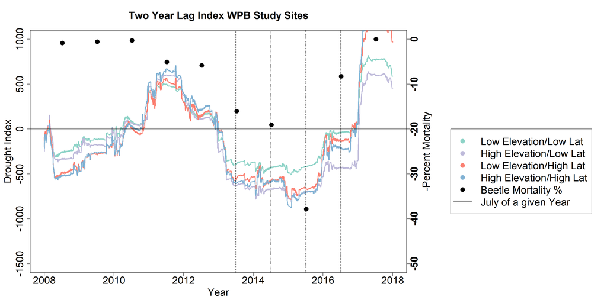

## One Year Lag

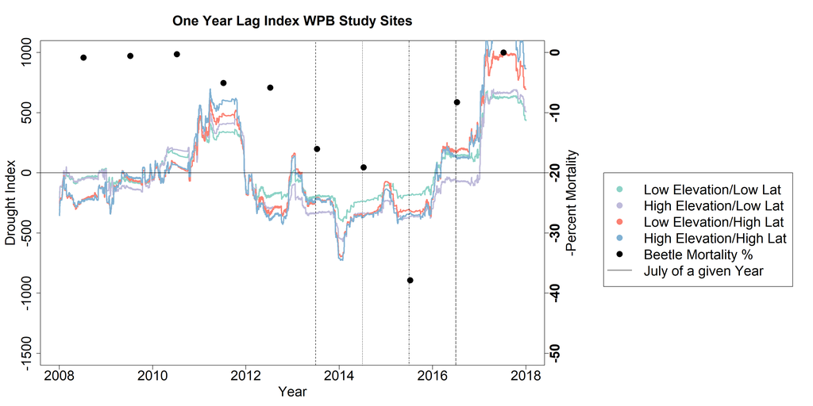

### Six Month Lag

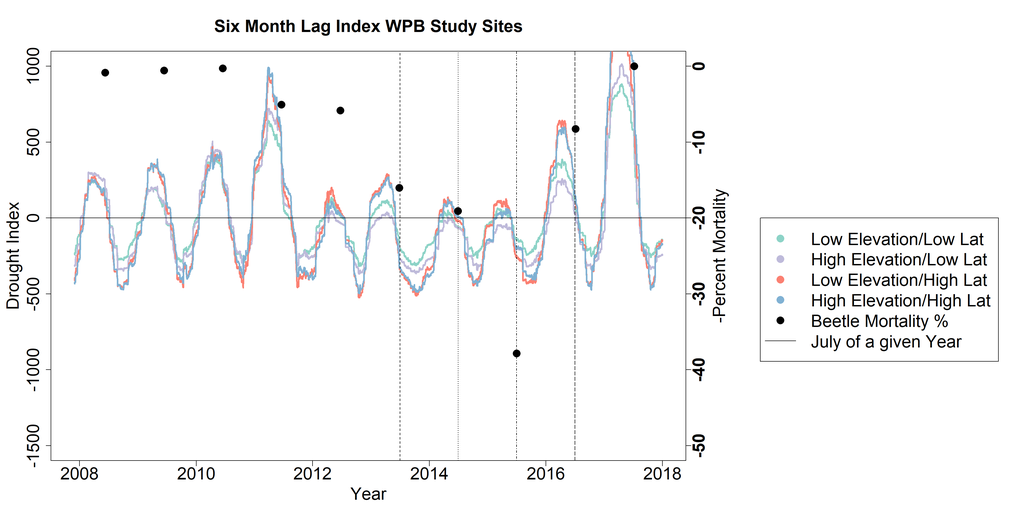

### Daily

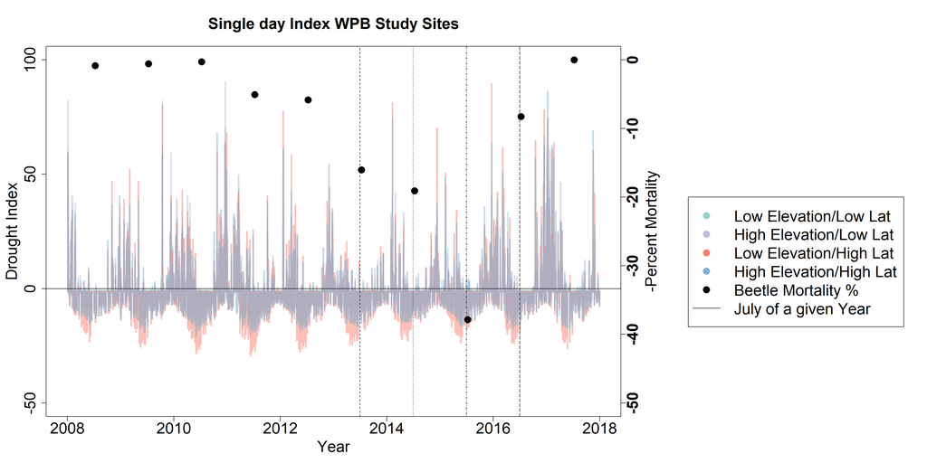